# Plastics Energies

The main focus materials are EVA, PET, and PVDF.

EVA, the encapsulant, is made from ethylene and vinyl acetate.

PET, a standard plastic, is well documented and typically forms a layer of the backsheet. PET is the polymerization of ethylene.

PVF, also known as Tedlar, is part of the backsheet and is formed by: PVF<-vinylfluoride<-difluoroethane<-acetylene<-natgas (ecoinvent). PVDF, also known as Kynar is similar and newer. Both formulations are proprietary and exact synthesis is unknown.

```python
import numpy as np
import pandas as pd
import os,sys
import matplotlib.pyplot as plt
plt.rcParams.update({'font.size': 18})
plt.rcParams['figure.figsize'] = (10, 6)
cwd = os.getcwd() #grabs current working directory
```

```python
cwd = os.getcwd() #grabs current working directory
#skipcols = ['Source', 'Notes','Country']
e_peteva_mfging_raw = pd.read_csv(cwd+"/../../../PV_ICE/baselines/SupportingMaterial/energy-input-plastics-mfging.csv",
                                     index_col='year')#, usecols=lambda x: x not in skipcols)
```

```python
e_peteva_mfging_raw.dropna(how='all')
```

| year | E_mfg_kWhpkg | Source | Notes | E_mfg_FUEL_kWhpkg | Source.1 | Notes.1 |
| --- | --- | --- | --- | --- | --- | --- |
| 1980 | 0.781000 | Brown, H.L. (1996) Energy Analysis of 108 Indu... | LDPE pg. 148-150, convert BTU to kWh, | 1.030000 | Brown, H.L. (1996) Energy Analysis of 108 Indu... | LDPE fuel for boiler (makes process steam) and... |
| 1981 | 0.232406 | Brown, H.L. (1996) Energy Analysis of 108 Indu... | unknown plastic, pg 152-153 | 1.385521 | Brown, H.L. (1996) Energy Analysis of 108 Indu... | LDPE fuel for boiler (makes process steam) and... |
| 1990 | 0.003333 | Joosten, L.A.J. (1998) Process Data Descriptio... | CED of new cracker plants, ethylene | NaN | NaN | NaN |
| 1994 | 0.833300 | Harding, K.G. et al. (2007) ‘Environmental ana... | Frischknecht and Suter 1996, LDPE electricity,... | NaN | NaN | NaN |
| 1995 | 19.000000 | G. J. M. Phylipsen and E. A. Alsema, “Environm... | CED "rough estimate" based off higher than pol... | 3.944440 | Joosten, L.A.J. (1998) Process Data Descriptio... | Table 38, polymerization PET, steam, ethylene |
| 1996 | 0.916700 | Joosten, L.A.J. (1998) Process Data Descriptio... | Table 38, polymerization PET, electricity | 0.861110 | Joosten, L.A.J. (1998) Process Data Descriptio... | Table 38, polymerization PET, gas, ethylene |
| 1997 | 0.056000 | Joosten, L.A.J. (1998) Process Data Descriptio... | Steamcracking is primary production of ethylen... | 2.888890 | Joosten, L.A.J. (1998) Process Data Descriptio... | Table 38, polymerization PET, fuel, ethylene |
| 1998 | 0.083300 | Holmgren, K.M. et al. (2014) ‘Gasification-bas... | Table 1, based on Joosten 1998, ethylene produ... | 1.083333 | Holmgren, K.M. et al. (2014) ‘Gasification-bas... | Table 1, based on Joosten 1998, ethylene produ... |
| 2000 | 0.494655 | Ecoinvent 2 | EVA copolymer production+ethylene production*1... | 1.161000 | Ecoinvent 2 | EVA copolymer production +vinyl acetate produc... |
| 2006 | 0.166670 | Liptow, C. and Tillman, A.-M. (2009) Comparati... | LDPE Table 5 (attributional) figure from Shell... | 0.888900 | Liptow, C. and Tillman, A.-M. (2009) Comparati... | LDPE Table 5 figure from Shell Raffinaderi 2007 |
| 2007 | 1.138890 | Liptow, C. and Tillman, A.-M. (2009) Comparati... | from Statoil Hydro 2007, pg 26, extract offsho... | NaN | NaN | NaN |
| 2008 | 1.361110 | Liptow, C. and Tillman, A.-M. (2009) Comparati... | LDPE Table 7 (attributional) naptha cracking | 4.166700 | Liptow, C. and Tillman, A.-M. (2009) Comparati... | LDPE Table 7 naptha cracking |
| 2009 | 3.722210 | Liptow, C. and Tillman, A.-M. (2009) Comparati... | LDPE table 10 polymerization, produces plastic... | 0.083300 | Liptow, C. and Tillman, A.-M. (2009) Comparati... | LDPE Table 10 polymerization |
| 2010 | 0.211110 | EPD: Ethylene, Propylene, Butadiene, Pyrolysis... | data 2007-2010, Table 16, ethylene electricity | 3.500000 | EPD: Ethylene, Propylene, Butadiene, Pyrolysis... | ethylene Table 16, heat/thermal E |
| 2011 | 6.222200 | EPD: Ethylene, Propylene, Butadiene, Pyrolysis... | data 2007-2010, Table 6, ethylene Total Proces... | 0.000000 | EPD: Ethylene, Propylene, Butadiene, Pyrolysis... | data 2007-2010, Table 6, ethylene Total Proces... |
| 2014 | 0.259000 | Ecoinvent 3.8 cutoff | LLDPE, virgin resin at plant, fuel in m3 | NaN | NaN | NaN |
| 2015 | 0.230000 | Ecoinvent 3.8 cutoff | PET virgin resin, usa, fuel in m3 | NaN | NaN | NaN |
| 2018 | 3.880000 | Nicholson, S.R. et al. (2021) ‘Manufacturing e... | Table S3, LLDPE "net fuel and net renewable fo... | 2.722215 | Nicholson, S.R. et al. (2021) ‘Manufacturing e... | Table S3, LLDPE "Net Process Fuel", most of th... |
| 2019 | 1.908333 | Nicholson, S.R. et al. (2021) ‘Manufacturing e... | Table S3, EVA "net fuel and net renewable for ... | 1.527773 | Nicholson, S.R. et al. (2021) ‘Manufacturing e... | Table S3, EVA "Net Process Fuel", most of the ... |
| 2022 | 29.722139 | Uekert, T. et al. (2023) ‘Technical, Economic,... | Table S27, PET Virgin, CED | NaN | NaN | NaN |

```python
e_peteva_mfging_CEDs = e_peteva_mfging_raw[e_peteva_mfging_raw['Notes'].str.contains('CED', na = False)]
e_peteva_mfging_CEDs
```

| year | E_mfg_kWhpkg | Source | Notes | E_mfg_FUEL_kWhpkg | Source.1 | Notes.1 |
| --- | --- | --- | --- | --- | --- | --- |
| 1990 | 0.003333 | Joosten, L.A.J. (1998) Process Data Descriptio... | CED of new cracker plants, ethylene | NaN | NaN | NaN |
| 1994 | 0.833300 | Harding, K.G. et al. (2007) ‘Environmental ana... | Frischknecht and Suter 1996, LDPE electricity,... | NaN | NaN | NaN |
| 1995 | 19.000000 | G. J. M. Phylipsen and E. A. Alsema, “Environm... | CED "rough estimate" based off higher than pol... | 3.94444 | Joosten, L.A.J. (1998) Process Data Descriptio... | Table 38, polymerization PET, steam, ethylene |
| 2011 | 6.222200 | EPD: Ethylene, Propylene, Butadiene, Pyrolysis... | data 2007-2010, Table 6, ethylene Total Proces... | 0.00000 | EPD: Ethylene, Propylene, Butadiene, Pyrolysis... | data 2007-2010, Table 6, ethylene Total Proces... |
| 2022 | 29.722139 | Uekert, T. et al. (2023) ‘Technical, Economic,... | Table S27, PET Virgin, CED | NaN | NaN | NaN |

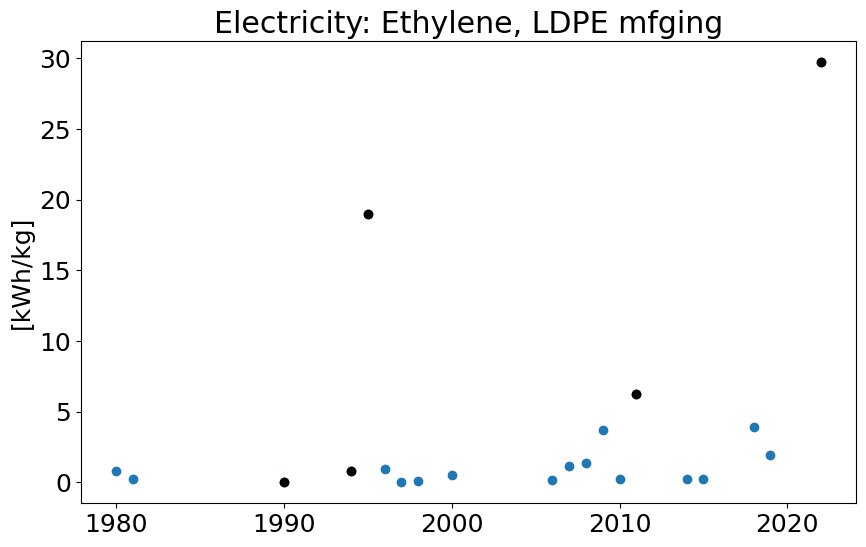

```python
plt.scatter(e_peteva_mfging_raw.index,e_peteva_mfging_raw.iloc[:,0])
plt.scatter(e_peteva_mfging_CEDs.index, e_peteva_mfging_CEDs.iloc[:,0], color='black')
plt.title('Electricity: Ethylene, LDPE mfging')
plt.ylabel('[kWh/kg]')
```

```python
e_peteva_mfging_CEDs.index
```

```
Int64Index([1990, 1994, 1995, 2011, 2022], dtype='int64', name='year')
```

```python
e_peteva_mfging = e_peteva_mfging_raw
e_peteva_mfging.loc[e_peteva_mfging_CEDs.index,:]=np.nan
#e_peteva_mfging.head(20)
```

```python
e_peteva_mfging_PET = e_peteva_mfging[e_peteva_mfging['Notes'].str.contains('PET', na = False)]
e_peteva_mfging_LDPE = e_peteva_mfging[e_peteva_mfging['Notes'].str.contains('LDPE', na = False)]
e_peteva_mfging_ethylene = e_peteva_mfging[e_peteva_mfging['Notes'].str.contains('ethylene', na = False)]
e_peteva_mfging_eva = e_peteva_mfging[e_peteva_mfging['Notes'].str.contains('EVA', na = False)]
```

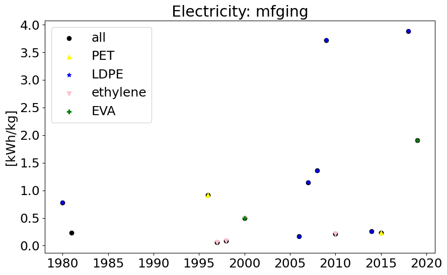

```python
plt.scatter(e_peteva_mfging.index,e_peteva_mfging.iloc[:,0], label='all', color='black')
plt.scatter(e_peteva_mfging_PET.index,e_peteva_mfging_PET.iloc[:,0], label='PET', color='yellow', marker='^')
plt.scatter(e_peteva_mfging_LDPE.index,e_peteva_mfging_LDPE.iloc[:,0], label='LDPE', color='blue', marker='*')
plt.scatter(e_peteva_mfging_ethylene.index,e_peteva_mfging_ethylene.iloc[:,0], label='ethylene', color='pink', marker='v')
plt.scatter(e_peteva_mfging_eva.index,e_peteva_mfging_eva.iloc[:,0], label='EVA', color='green', marker='P')
plt.title('Electricity: mfging')
plt.ylabel('[kWh/kg]')
plt.legend()
```

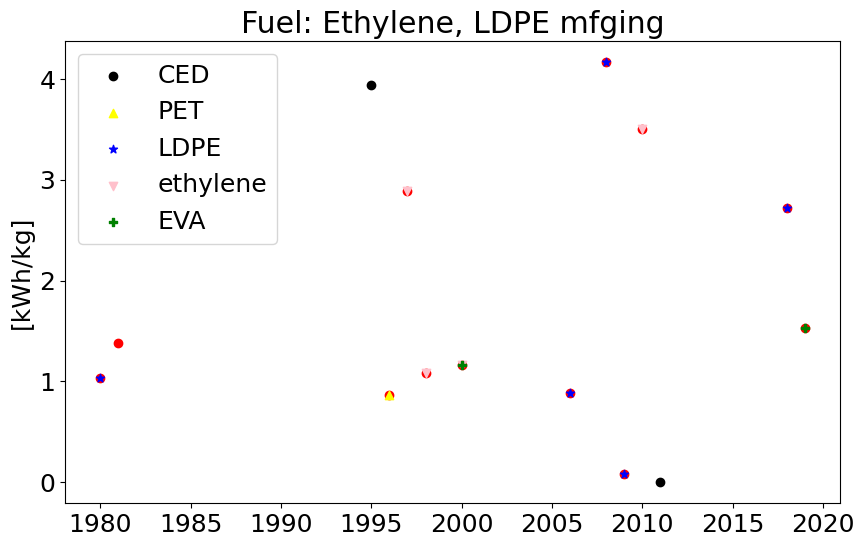

```python
plt.scatter(e_peteva_mfging_raw.index,e_peteva_mfging_raw.iloc[:,3], color='red')
plt.scatter(e_peteva_mfging_CEDs.index, e_peteva_mfging_CEDs.iloc[:,3], color='black', label='CED')

plt.scatter(e_peteva_mfging_PET.index,e_peteva_mfging_PET.iloc[:,3], label='PET', color='yellow', marker='^')
plt.scatter(e_peteva_mfging_LDPE.index,e_peteva_mfging_LDPE.iloc[:,3], label='LDPE', color='blue', marker='*')
plt.scatter(e_peteva_mfging_ethylene.index,e_peteva_mfging_ethylene.iloc[:,3], label='ethylene', color='pink', marker='v')
plt.scatter(e_peteva_mfging_eva.index,e_peteva_mfging_eva.iloc[:,3], label='EVA', color='green', marker='P')

plt.title('Fuel: Ethylene, LDPE mfging')
plt.ylabel('[kWh/kg]')
plt.legend()
```

```python
# sum the electricity and fuel
e_peteva_mfging['E_mfg_sum_kWhpkg'] = e_peteva_mfging['E_mfg_kWhpkg']+e_peteva_mfging['E_mfg_FUEL_kWhpkg']
```

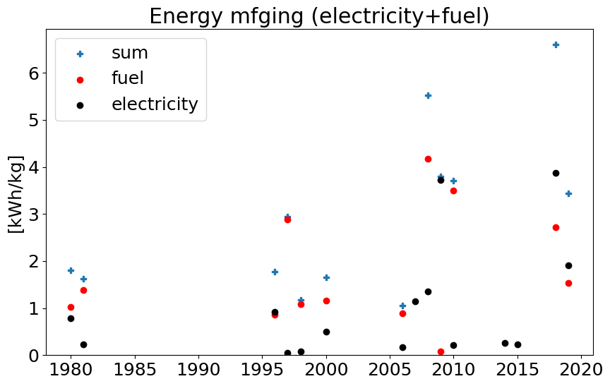

```python
plt.scatter(e_peteva_mfging_raw.index,e_peteva_mfging['E_mfg_sum_kWhpkg'], marker='P', label='sum')
plt.scatter(e_peteva_mfging_raw.index,e_peteva_mfging_raw.iloc[:,3], label='fuel', color='red')
plt.scatter(e_peteva_mfging.index,e_peteva_mfging.iloc[:,0], label='electricity', color='black')
plt.title('Energy mfging (electricity+fuel)')
plt.ylabel('[kWh/kg]')
plt.ylim(0,)
plt.legend()
```

```python
e_peteva_mfging_PET = e_peteva_mfging[e_peteva_mfging['Notes'].str.contains('PET', na = False)]
e_peteva_mfging_LDPE = e_peteva_mfging[e_peteva_mfging['Notes'].str.contains('LDPE', na = False)]
e_peteva_mfging_ethylene = e_peteva_mfging[e_peteva_mfging['Notes'].str.contains('ethylene', na = False)]
e_peteva_mfging_eva = e_peteva_mfging[e_peteva_mfging['Notes'].str.contains('EVA', na = False)]
```

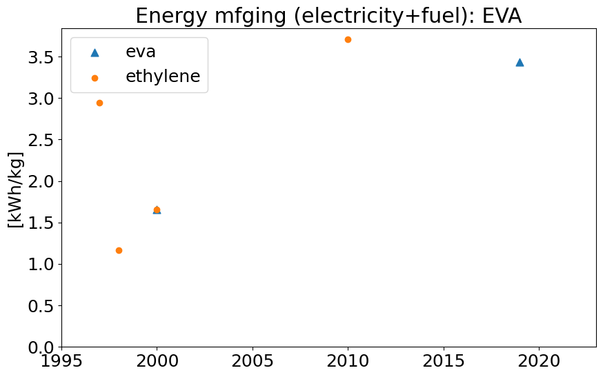

```python
plt.scatter(e_peteva_mfging_eva.index, e_peteva_mfging_eva['E_mfg_sum_kWhpkg'], label='eva', marker='^', s=60)
plt.scatter(e_peteva_mfging_ethylene.index, e_peteva_mfging_ethylene['E_mfg_sum_kWhpkg'], label='ethylene')
plt.title('Energy mfging (electricity+fuel): EVA')
plt.ylabel('[kWh/kg]')
plt.xlim(1995,2023)
plt.ylim(0,)
plt.legend()
```

```python
e_peteva_mfging_eva
```

| year | E_mfg_kWhpkg | Source | Notes | E_mfg_FUEL_kWhpkg | Source.1 | Notes.1 | E_mfg_sum_kWhpkg |
| --- | --- | --- | --- | --- | --- | --- | --- |
| 2000 | 0.494655 | Ecoinvent 2 | EVA copolymer production+ethylene production*1... | 1.161000 | Ecoinvent 2 | EVA copolymer production +vinyl acetate produc... | 1.655655 |
| 2019 | 1.908333 | Nicholson, S.R. et al. (2021) ‘Manufacturing e... | Table S3, EVA "net fuel and net renewable for ... | 1.527773 | Nicholson, S.R. et al. (2021) ‘Manufacturing e... | Table S3, EVA "Net Process Fuel", most of the ... | 3.436106 |

```python
e_peteva_mfging_ethylene
```

| year | E_mfg_kWhpkg | Source | Notes | E_mfg_FUEL_kWhpkg | Source.1 | Notes.1 | E_mfg_sum_kWhpkg |
| --- | --- | --- | --- | --- | --- | --- | --- |
| 1997 | 0.056000 | Joosten, L.A.J. (1998) Process Data Descriptio... | Steamcracking is primary production of ethylen... | 2.888890 | Joosten, L.A.J. (1998) Process Data Descriptio... | Table 38, polymerization PET, fuel, ethylene | 2.944890 |
| 1998 | 0.083300 | Holmgren, K.M. et al. (2014) ‘Gasification-bas... | Table 1, based on Joosten 1998, ethylene produ... | 1.083333 | Holmgren, K.M. et al. (2014) ‘Gasification-bas... | Table 1, based on Joosten 1998, ethylene produ... | 1.166633 |
| 2000 | 0.494655 | Ecoinvent 2 | EVA copolymer production+ethylene production*1... | 1.161000 | Ecoinvent 2 | EVA copolymer production +vinyl acetate produc... | 1.655655 |
| 2010 | 0.211110 | EPD: Ethylene, Propylene, Butadiene, Pyrolysis... | data 2007-2010, Table 16, ethylene electricity | 3.500000 | EPD: Ethylene, Propylene, Butadiene, Pyrolysis... | ethylene Table 16, heat/thermal E | 3.711110 |

Ethylene is used to make EVA at ~1:1, the vinyl acetate component is lower, ~20%. It is still disturbing that the energy for ethylene seems to be higher than the sum of the processes for EVA...

I am going to take the 2000 value from Ecoinvent and Nicholson et al 2021 using MFI data from 2019 and interpolate for EVA.

## EVA: granulate production

```python
idx_temp = pd.Series(range(1995,2051,1))
E_mfg_eva_temp = pd.DataFrame(index=idx_temp)
E_mfg_eva_temp.loc[2000,'E_mfg_eva_kWhpkg'] = e_peteva_mfging_eva.loc[2000,'E_mfg_sum_kWhpkg']
E_mfg_eva_temp.loc[2019,'E_mfg_eva_kWhpkg'] = e_peteva_mfging_eva.loc[2019,'E_mfg_sum_kWhpkg']
E_mfg_eva_temp.loc[2000,'E_mfg_eva_fuelfraction'] = e_peteva_mfging_eva.loc[2000,'E_mfg_FUEL_kWhpkg']/e_peteva_mfging_eva.loc[2000,'E_mfg_sum_kWhpkg']
E_mfg_eva_temp.loc[2019,'E_mfg_eva_fuelfraction'] = e_peteva_mfging_eva.loc[2000,'E_mfg_FUEL_kWhpkg']/e_peteva_mfging_eva.loc[2019,'E_mfg_sum_kWhpkg']
```

```python
E_mfg_eva = E_mfg_eva_temp.interpolate(limit_direction='both')
```

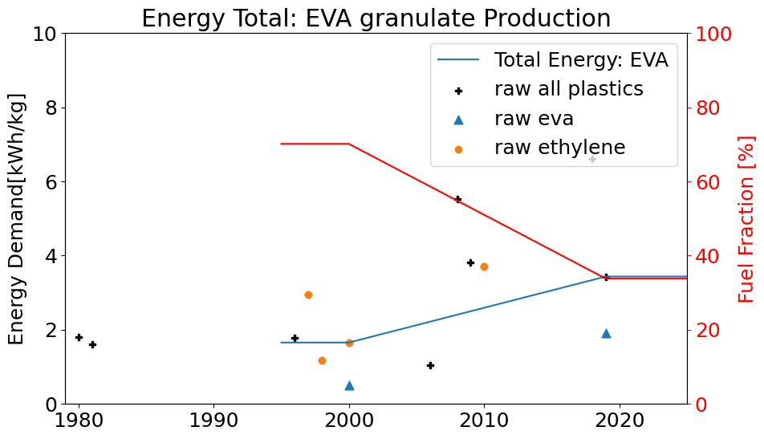

```python
fig, ax1 = plt.subplots()

ax1.plot(E_mfg_eva['E_mfg_eva_kWhpkg'], label='Total Energy: EVA')
plt.scatter(e_peteva_mfging_raw.index,e_peteva_mfging['E_mfg_sum_kWhpkg'], marker='P', color='black', label='raw all plastics')
ax1.scatter(e_peteva_mfging_eva.index,e_peteva_mfging_eva.iloc[:,0], label='raw eva', marker='^', s=60)
plt.scatter(e_peteva_mfging_ethylene.index, e_peteva_mfging_ethylene['E_mfg_sum_kWhpkg'], label='raw ethylene')

ax1.set_ylim(0,10)
ax1.set_ylabel('Energy Demand[kWh/kg]')

ax2 = ax1.twinx()
ax2.plot(E_mfg_eva['E_mfg_eva_fuelfraction']*100, color='red', label='Fuel Fraction')
#ax2.scatter(E_mfg_eva.index,E_mfg_eva.iloc[:,1], color='red', marker='^', label='fuel fraction data')
ax2.set_ylim(0,100)
plt.ylabel('Fuel Fraction [%]', color='red')
ax2.tick_params(axis='y', color='red', labelcolor='red')

plt.xlim(1979,2025)
plt.title('Energy Total: EVA granulate Production')

ax1.legend(loc='upper right')
#ax2.legend(loc='upper right')
plt.show()
```

# PET

All backsheet materials that are not PP based (which is a small marketshare) have a PET interlayer. Therefore, we will include the energy of PET manufacture to add to PVDF for creating backsheet energy flows.

```python
cwd = os.getcwd() #grabs current working directory
#skipcols = ['Source', 'Notes','Country']
e_backsheetPET_mfg_raw = pd.read_csv(cwd+"/../../../PV_ICE/baselines/SupportingMaterial/energy-input-backsheetPET-mfging.csv",
                                     index_col='year')#, usecols=lambda x: x not in skipcols)
```

```python
e_backsheetPET_mfg_raw.dropna(how='all')
```

| year | E_mfg_kWhpkg | Source | Notes | E_mfg_FUEL_kWhpkg | Source.1 | Notes.1 |
| --- | --- | --- | --- | --- | --- | --- |
| 1995 | 0.916700 | Joosten, L.A.J. (1998) Process Data Descriptio... | Table 38, polymerization PET, electricity | 7.694440 | Joosten, L.A.J. (1998) Process Data Descriptio... | Table 38, polymerization PET, steam |
| 2005 | 3.466570 | Boustead, I. 2005. “Eco-Profiles of the Europe... | Table 1, PET, electricity | 0.316666 | Boustead, I. 2005. “Eco-Profiles of the Europe... | Table 1, PET, oil fuels and other fuels column 1 |
| 2007 | 0.194444 | Neelis, Maarten, Martin Patel, Kornelis Blok, ... | Appendix A PET, electricity use | 1.125000 | Neelis, Maarten, Martin Patel, Kornelis Blok, ... | Appendix A, PET, fuel+steam |
| 2015 | 0.230000 | Ecoinvent 3.8 cutoff | PET virgin resin, usa | 0.000000 | Ecoinvent | there is nat gas and fuel oil, but measured in m3 |
| 2018 | 23.907340 | Camaratta, Rubens, Tiago Moreno Volkmer, and A... | Table 2, PET, embodied energy likely CED | 0.000000 | because embodied e | NaN |
| 2019 | 1.102000 | Tamburini, Elena, Stefania Costa, Daniela Summ... | Table 1, PET, sum of electricities | 3.475000 | Tamburini, Elena, Stefania Costa, Daniela Summ... | Table 1, PET, sum of heat |
| 2020 | 29.722139 | Uekert, T. et al. (2023) ‘Technical, Economic,... | Table S27, PET Virgin, CED | 0.000000 | because embodied e | NaN |

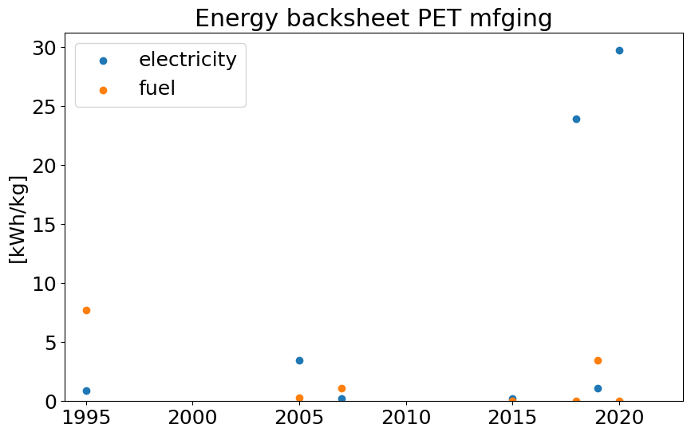

```python
plt.scatter(e_backsheetPET_mfg_raw.index, e_backsheetPET_mfg_raw.iloc[:,0], label='electricity', )
plt.scatter(e_backsheetPET_mfg_raw.index, e_backsheetPET_mfg_raw.iloc[:,3], label='fuel')
plt.title('Energy backsheet PET mfging')
plt.ylabel('[kWh/kg]')
plt.xlim(1994,2023)
plt.ylim(0,)
plt.legend()
```

The two high points are CEDs. Exclude and replot

```python
e_backsheetPET_mfg = e_backsheetPET_mfg_raw.copy()
e_backsheetPET_mfg.loc[2018] = np.nan
e_backsheetPET_mfg.loc[2020] = np.nan

e_backsheetPET_mfg['E_sum_kWhpkg'] = e_backsheetPET_mfg['E_mfg_kWhpkg']+e_backsheetPET_mfg['E_mfg_FUEL_kWhpkg']
e_backsheetPET_mfg['E_fuelfraction_kWhpkg'] = e_backsheetPET_mfg['E_mfg_FUEL_kWhpkg']/e_backsheetPET_mfg['E_sum_kWhpkg']
```

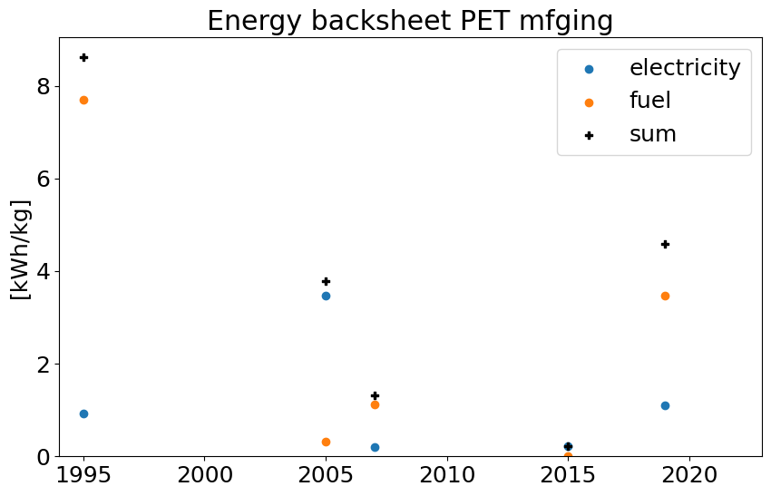

```python
plt.scatter(e_backsheetPET_mfg.index, e_backsheetPET_mfg.iloc[:,0], label='electricity', )
plt.scatter(e_backsheetPET_mfg.index, e_backsheetPET_mfg.iloc[:,3], label='fuel')
plt.scatter(e_backsheetPET_mfg.index, e_backsheetPET_mfg.iloc[:,6], label='sum', marker='P', color='black')

plt.title('Energy backsheet PET mfging')
plt.ylabel('[kWh/kg]')
plt.xlim(1994,2023)
plt.ylim(0,)
plt.legend()
```

```python
e_backsheetPET_mfg.dropna(how='all')
```

| year | E_mfg_kWhpkg | Source | Notes | E_mfg_FUEL_kWhpkg | Source.1 | Notes.1 | E_sum_kWhpkg | E_fuelfraction_kWhpkg |
| --- | --- | --- | --- | --- | --- | --- | --- | --- |
| 1995 | 0.916700 | Joosten, L.A.J. (1998) Process Data Descriptio... | Table 38, polymerization PET, electricity | 7.694440 | Joosten, L.A.J. (1998) Process Data Descriptio... | Table 38, polymerization PET, steam | 8.611140 | 0.893545 |
| 2005 | 3.466570 | Boustead, I. 2005. “Eco-Profiles of the Europe... | Table 1, PET, electricity | 0.316666 | Boustead, I. 2005. “Eco-Profiles of the Europe... | Table 1, PET, oil fuels and other fuels column 1 | 3.783235 | 0.083702 |
| 2007 | 0.194444 | Neelis, Maarten, Martin Patel, Kornelis Blok, ... | Appendix A PET, electricity use | 1.125000 | Neelis, Maarten, Martin Patel, Kornelis Blok, ... | Appendix A, PET, fuel+steam | 1.319444 | 0.852632 |
| 2015 | 0.230000 | Ecoinvent 3.8 cutoff | PET virgin resin, usa | 0.000000 | Ecoinvent | there is nat gas and fuel oil, but measured in m3 | 0.230000 | 0.000000 |
| 2019 | 1.102000 | Tamburini, Elena, Stefania Costa, Daniela Summ... | Table 1, PET, sum of electricities | 3.475000 | Tamburini, Elena, Stefania Costa, Daniela Summ... | Table 1, PET, sum of heat | 4.577000 | 0.759231 |

With this lovely scatter plot, we're going to use 4 kWh/kg for total energy and fuel fraction of 80%

```python
idx_temp = pd.Series(range(1995,2051,1))
E_mfg_pet = pd.DataFrame(index=idx_temp)
E_mfg_pet.loc[:,'E_mfg_pet_kWhpkg'] = 4.0
E_mfg_pet.loc[:,'E_mfg_pet_fuelfraction'] = 0.8
```

# PVDF granulate energy

PVDF and PVF

```python
cwd = os.getcwd() #grabs current working directory
#skipcols = ['Source', 'Notes','Country']
e_backsheet_mfg_raw = pd.read_csv(cwd+"/../../../PV_ICE/baselines/SupportingMaterial/energy-input-backsheet-mfging.csv",
                                     index_col='year')#, usecols=lambda x: x not in skipcols)
```

```python
e_backsheet_mfg_raw.dropna(how='all')
```

| year | E_mfg_kWhpkg | Source | Notes | E_mfg_FUEL_kWhpkg | Source.1 | Notes.1 |
| --- | --- | --- | --- | --- | --- | --- |
| 1995 | 19.000000 | G. J. M. Phylipsen and E. A. Alsema, “Environm... | "rough estimate" based off higher than polyeth... | 0.000000 | NaN | NaN |
| 2005 | 7.152000 | EcoInvent V2, Dupont 2005 | sum of electricity in processes natgas->PVF di... | 17.555000 | EcoInvent V2, Dupont 2005 | sum of energy fuels and heat in processes natg... |
| 2011 | 31.110000 | Abbasi, Salman Ali. 2014. “Exergetic Life Cycl... | Route 2, table 6 | 0.000000 | Abbasi, Salman Ali. 2014. “Exergetic Life Cycl... | unspecified eletricity vs fuel |
| 2012 | 28.330000 | Abbasi, Salman Ali. 2014. “Exergetic Life Cycl... | Route 1 , table 6 | 0.000000 | Abbasi, Salman Ali. 2014. “Exergetic Life Cycl... | unspecified eletricity vs fuel |
| 2013 | 0.694442 | Abbasi, Salman Ali. 2014. “Exergetic Life Cycl... | Route 2, page 33 Table 5 (ratio in table 6 is ... | 0.555554 | Abbasi, Salman Ali. 2014. “Exergetic Life Cycl... | Route 2, page 33 Table 5 |
| 2014 | 7.272221 | Abbasi, Salman Ali. 2014. “Exergetic Life Cycl... | Route 1 page30+pg31+pg32 table 4 | 24.131044 | Abbasi, Salman Ali. 2014. “Exergetic Life Cycl... | Route 1 heating for pyrolysis, page 29+pg30 he... |
| 2021 | 13.681290 | Hu, Xiaomeng, Alicia K. J. An, and Shauhrat S.... | Route 2 - assumes electrical heating, patents ... | 0.000000 | NaN | NaN |
| 2022 | 49.551600 | Hu, Xiaomeng, Alicia K. J. An, and Shauhrat S.... | Route 1 - assumes electrical heating, patents ... | 0.000000 | NaN | NaN |

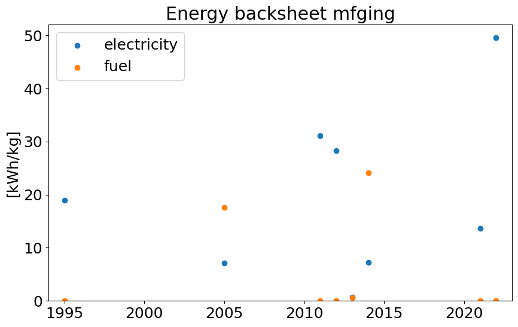

```python
plt.scatter(e_backsheet_mfg_raw.index, e_backsheet_mfg_raw.iloc[:,0], label='electricity', )
plt.scatter(e_backsheet_mfg_raw.index, e_backsheet_mfg_raw.iloc[:,3], label='fuel')
plt.title('Energy backsheet mfging')
plt.ylabel('[kWh/kg]')
plt.xlim(1994,2023)
plt.ylim(0,)
plt.legend()
```

```python
e_backsheet_mfg_route1 = e_backsheet_mfg_raw[e_backsheet_mfg_raw['Notes'].str.contains('Route 1', na = False)]
e_backsheet_mfg_route2 = e_backsheet_mfg_raw[e_backsheet_mfg_raw['Notes'].str.contains('Route 2', na = False)]
e_backsheet_mfg_raw['E_sum_kWhpkg'] = e_backsheet_mfg_raw['E_mfg_kWhpkg']+e_backsheet_mfg_raw['E_mfg_FUEL_kWhpkg']
```

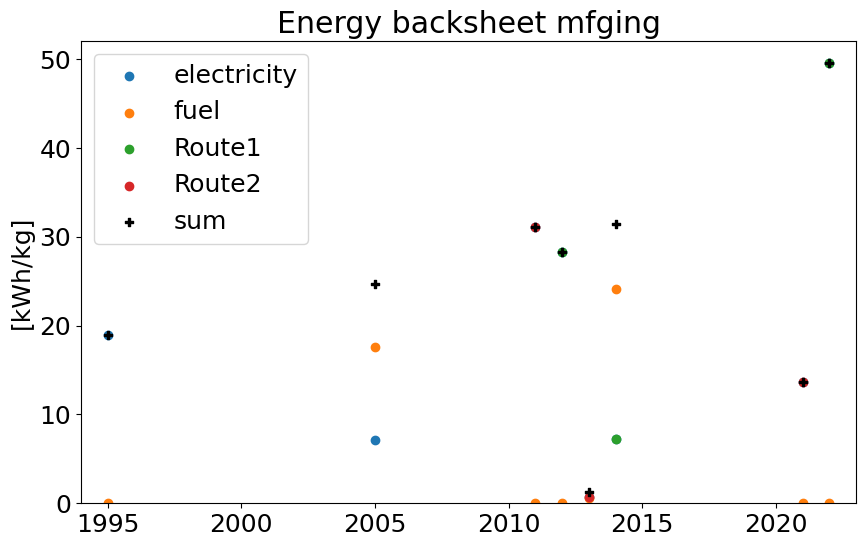

```python
plt.scatter(e_backsheet_mfg_raw.index, e_backsheet_mfg_raw.iloc[:,0], label='electricity', )
plt.scatter(e_backsheet_mfg_raw.index, e_backsheet_mfg_raw.iloc[:,3], label='fuel')

plt.scatter(e_backsheet_mfg_route1.index, e_backsheet_mfg_route1.iloc[:,0], label='Route1')
plt.scatter(e_backsheet_mfg_route2.index, e_backsheet_mfg_route2.iloc[:,0], label='Route2')

plt.scatter(e_backsheet_mfg_raw.index, e_backsheet_mfg_raw.loc[:,'E_sum_kWhpkg'], label='sum', color='black', marker='P')

plt.title('Energy backsheet mfging')
plt.ylabel('[kWh/kg]')
plt.xlim(1994,2023)
plt.ylim(0,)
plt.legend()
```

Therefore, we will use the average of the two routes from Abbasi and apply the higher fuel fraction (there a several heating steps that at industrial scale are likely to be done with natgas.

```python
mean_abbasi = (e_backsheet_mfg_raw.loc[2011,'E_mfg_kWhpkg']+e_backsheet_mfg_raw.loc[2012,'E_mfg_kWhpkg'])/2
print('The average of Abbasi Route 1 and 2 is '+str(mean_abbasi)+' kWh/kg')
```

```
The average of Abbasi Route 1 and 2 is 29.72 kWh/kg
```

```python
fuelfraction_abbasi = e_backsheet_mfg_raw.loc[2014,'E_mfg_FUEL_kWhpkg']/e_backsheet_mfg_raw.loc[2014,'E_sum_kWhpkg']
print('The fuel fraction of Abassi from Route 1 is '+str(fuelfraction_abbasi))
```

```
The fuel fraction of Abassi from Route 1 is 0.7684246698551886
```

```python
idx_temp = pd.Series(range(1995,2051,1))
E_mfg_pvdf = pd.DataFrame(index=idx_temp)
E_mfg_pvdf.loc[:,'E_mfg_pvdf_kWhpkg'] = mean_abbasi
E_mfg_pvdf.loc[:,'E_mfg_pvdfFUEL_fraction'] = fuelfraction_abbasi
```

# Forming energy

Turning granulate polymer into sheets

```python
cwd = os.getcwd() #grabs current working directory
#skipcols = ['Source', 'Notes','Country']
e_plastic_sheet_raw = pd.read_csv(cwd+"/../../../PV_ICE/baselines/SupportingMaterial/energy-input-plastic-forming.csv",
                                     index_col='year')#, usecols=lambda x: x not in skipcols)
```

```python
e_plastic_sheet_raw.dropna(how='all')
```

| year | E_mfg_kWhpkg | Source | Notes | E_mfg_FUEL_kWhpkg | Source.1 | Notes.1 |
| --- | --- | --- | --- | --- | --- | --- |
| 1993 | 1.27803 | Ecoinvent 2 | per kg input, extrusion of plastic film | 0.225027 | Ecoinvent 2 | per kg input, heating natural gas, extrusion o... |
| 1997 | 0.52778 | Joosten, L.A.J. (1998) Process Data Descriptio... | Table 47, film extrusion, electricity, from No... | 0.000000 | Joosten, L.A.J. (1998) Process Data Descriptio... | Table 47, film extrusion, gas, from Novem 1997 |
| 2005 | 2.80520 | EcoInvent V2, Dupont 2005 | PVF film production electricity | 7.995011 | EcoInvent V2, Dupont 2005 | PVF film production heat from natgas |
| 2012 | 0.40000 | Dormer, A. et al. (2013) ‘Carbon footprint ana... | extrusion fit function, fig 7 a 10 kg/min (low... | 0.000000 | NaN | NaN |
| 2013 | 0.15278 | Li, W., Kara, S. and Kornfeld, B. (2013) ‘Deve... | experimental control of extruder, conf paper | 0.000000 | NaN | NaN |
| 2014 | 0.75000 | Deng, J. et al. (2014) ‘Energy monitoring and ... | Tables 5-7 avg-ish of total SEC of barrel scre... | 0.000000 | NaN | NaN |

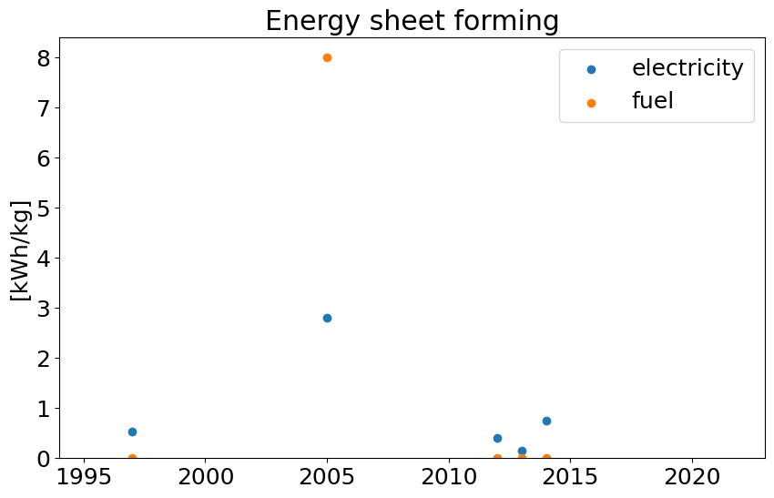

```python
plt.scatter(e_plastic_sheet_raw.index, e_plastic_sheet_raw.iloc[:,0], label='electricity', )
plt.scatter(e_plastic_sheet_raw.index, e_plastic_sheet_raw.iloc[:,3], label='fuel')
plt.title('Energy sheet forming')
plt.ylabel('[kWh/kg]')
plt.xlim(1994,2023)
plt.ylim(0,)
plt.legend()
```

Based on the assumption that the energy required to form the film from a granualate is unlikely to be greater than the energy to create the granualte from feedstock, we will remove the high outlier, and average the rest.

```python
e_plastic_sheet = e_plastic_sheet_raw.copy()
e_plastic_sheet.loc[2005] = np.nan
e_filmform = e_plastic_sheet.mean()
```

```python
e_filmform.sum()
```

```
0.6667234296
```

```python
idx_temp = pd.Series(range(1995,2051,1))
E_mfg_film = pd.DataFrame(index=idx_temp)
E_mfg_film.loc[:,'E_mfg_pvdf_kWhpkg'] = e_filmform.sum()
E_mfg_film.loc[:,'E_mfg_pvdfFUEL_fraction'] = e_filmform['E_mfg_FUEL_kWhpkg']/ e_filmform.sum()
```

# Sum and Weight manufacturing Energies

We need to add the film formation to each of the 3 plastics. Then EVA+film will be multiplied by the encapsulant baseline.

For the backsheet, the PET core is typically 200 um thick, with two layers of PVF or PVDF of 40 um thick. The mass of the backsheet was weighted by the relative thicknesses of each material. We also have weighting by Kynar, Tedlar, and other - however, we didn't find energy data to support this level of detail for energy weighting - we will assume that PVDF and PVF have similar energy of manufacture. We will use the same weighting factor for fraction of the backsheet attributable to PET vs PVF/PVDF as we did in the mass baseline, i.e.; 80/280 *pvf energy + 200/280* PET energy = average energy

### EVA+film = encapsuant energy manufacturing

```python
idx_temp = pd.Series(range(1995,2051,1))
E_encapsulant = pd.DataFrame(index=idx_temp)
E_encapsulant['E_mfg_kWhpkg'] = E_mfg_film['E_mfg_pvdf_kWhpkg'] + E_mfg_eva['E_mfg_eva_kWhpkg']
E_encapsulant['E_mfg_fuel_kWhpkg'] = e_filmform['E_mfg_FUEL_kWhpkg']+E_mfg_eva['E_mfg_eva_fuelfraction']*E_mfg_eva['E_mfg_eva_kWhpkg']
E_encapsulant['E_mfg_fuelfraction'] = 100*(E_encapsulant['E_mfg_fuel_kWhpkg']/E_encapsulant['E_mfg_kWhpkg'])
E_encapsulant_final = E_encapsulant.iloc[:,[0,2]]
#E_encapsulant_final
```

```python
E_encapsulant_final.head()
```

|  | E_mfg_kWhpkg | E_mfg_fuelfraction |
| --- | --- | --- |
| 1995 | 2.322378 | 51.929766 |
| 1996 | 2.322378 | 51.929766 |
| 1997 | 2.322378 | 51.929766 |
| 1998 | 2.322378 | 51.929766 |
| 1999 | 2.322378 | 51.929766 |

```python
E_encapsulant_final.to_csv(cwd+"/../../../PV_ICE/baselines/SupportingMaterial/output_energy_encapsulant_MFGing.csv")
```

### PVDF+Film and PET+film = backsheet energy manufacturing

*note all these values are static with time currently.*

```python
pvf_fraction = 80/280
pet_fraction = 200/280
```

```python
e_petfilm_kwhpkg = E_mfg_film['E_mfg_pvdf_kWhpkg'] + E_mfg_pet['E_mfg_pet_kWhpkg']
e_petfilm_fuelfraction = (E_mfg_film['E_mfg_pvdf_kWhpkg']*E_mfg_film['E_mfg_pvdfFUEL_fraction'] +
                          E_mfg_pet['E_mfg_pet_kWhpkg']*E_mfg_pet['E_mfg_pet_fuelfraction'])/e_petfilm_kwhpkg
e_petfilm_fuel_kwhpkg = (E_mfg_film['E_mfg_pvdf_kWhpkg']*E_mfg_film['E_mfg_pvdfFUEL_fraction'] +
                          E_mfg_pet['E_mfg_pet_kWhpkg']*E_mfg_pet['E_mfg_pet_fuelfraction'])
```

```python
e_pvdffilm_kwhpkg = E_mfg_film['E_mfg_pvdf_kWhpkg'] + E_mfg_pvdf['E_mfg_pvdf_kWhpkg']
e_pvdffilm_fuelfraction = (E_mfg_film['E_mfg_pvdf_kWhpkg']*E_mfg_film['E_mfg_pvdfFUEL_fraction'] +
                           E_mfg_pvdf['E_mfg_pvdf_kWhpkg']*E_mfg_pvdf['E_mfg_pvdfFUEL_fraction'])/e_pvdffilm_kwhpkg
e_pvdffilm_fuel_kwhpkg = (E_mfg_film['E_mfg_pvdf_kWhpkg']*E_mfg_film['E_mfg_pvdfFUEL_fraction'] +
                           E_mfg_pvdf['E_mfg_pvdf_kWhpkg']*E_mfg_pvdf['E_mfg_pvdfFUEL_fraction'])
```

```python
idx_temp = pd.Series(range(1995,2051,1))
E_backsheet = pd.DataFrame(index=idx_temp)
E_backsheet['E_mfg_kWhpkg'] = pvf_fraction * e_pvdffilm_kwhpkg + pet_fraction * e_petfilm_kwhpkg
E_backsheet['E_mfg_fuelfraction'] = 100*((pet_fraction *e_petfilm_fuel_kwhpkg+pvf_fraction *e_pvdffilm_fuel_kwhpkg)/E_backsheet['E_mfg_kWhpkg'])
```

```python
E_backsheet.head()
```

|  | E_mfg_kWhpkg | E_mfg_fuelfraction |
| --- | --- | --- |
| 1995 | 12.015295 | 73.703917 |
| 1996 | 12.015295 | 73.703917 |
| 1997 | 12.015295 | 73.703917 |
| 1998 | 12.015295 | 73.703917 |
| 1999 | 12.015295 | 73.703917 |

```python
E_backsheet.to_csv(cwd+"/../../../PV_ICE/baselines/SupportingMaterial/output_energy_backsheet_MFGing.csv")
```

# Landfill Energy

There was really only one plastic specific landfilling energy found; Xayachak, T. et al. (2023) ‘Assessing the environmental footprint of plastic pyrolysis and gasification: A life cycle inventory study’, Process Safety and Environmental Protection, 173, pp. 592–603. Available at: https://doi.org/10.1016/j.psep.2023.03.061. The energy denoted in Table S3 is miniscual: 4e-4 kWh/kg, mostly electricity. Previous material baselines have used 0.09 kWh/kg from Ravikumar 2016. We will maintain consistency, and use the 0.09 value.

There is a potential for incineration with heat/energy recovery, however, we will currently neglect this option and assume things are landfilled without incineration. Potential upgrades could include energy credit or negative energy, but would also require carbon intensity.

# Recycling Energies

Low Quality = Mechanical Recycling

High Quality = chemical recycling (pyrolysis or glycolysis)

We will not distingiush between recycling energies of the different plastics as little information was found, and mixed plastic recycling is uncommon (e.g.; backsheet)

```python
cwd = os.getcwd() #grabs current working directory
#skipcols = ['Source', 'Notes','Country']
e_plastic_LQrecycle_raw = pd.read_csv(cwd+"/../../../PV_ICE/baselines/SupportingMaterial/energy-input-plastic-LQrecycling.csv",
                                     index_col='year')#, usecols=lambda x: x not in skipcols)
```

```python
e_plastic_LQrecycle_raw['E_sum_kWhpkg'] = e_plastic_LQrecycle_raw['E_LQrecycle_kWhpkg']+e_plastic_LQrecycle_raw['E_LQrecycle_fuel_kWhpkg']
```

```python
e_plastic_LQrecycle_raw.dropna(how='all')
```

| year | E_LQrecycle_kWhpkg | Source | Notes | E_LQrecycle_fuel_kWhpkg | Source.1 | Notes.1 | E_sum_kWhpkg |
| --- | --- | --- | --- | --- | --- | --- | --- |
| 1997 | 0.833300 | Joosten, L.A.J. (1998) Process Data Descriptio... | MFG Scrap, possibly hq open loop?, pg 77 from ... | 0.000000 | NaN | NaN | 0.833300 |
| 1998 | 0.611100 | Joosten, L.A.J. (1998) Process Data Descriptio... | EoL recycling, pg 70 & 71, energy to upgrade p... | 1.333000 | Joosten, L.A.J. (1998) Process Data Descriptio... | pg 70 and Table 53, natural gas to upgrade pla... | 1.944100 |
| 2003 | 0.705554 | Arena, U., Mastellone, M.L. and Perugini, F. (... | Table 2, LQ Recycled PET, Electric energy of m... | 1.508329 | Arena, U., Mastellone, M.L. and Perugini, F. (... | Table 2, Recycled PET, Diesel and Methane of m... | 2.213883 |
| 2020 | 0.828000 | Uekert, T. et al. (2023) ‘Technical, Economic,... | S30, total energy of sorting at MRF | 0.000000 | NaN | NaN | 0.828000 |
| 2021 | 0.070000 | Uekert, T. et al. (2023) ‘Technical, Economic,... | S31, electricity of sorting at MRF | 0.000000 | NaN | NaN | 0.070000 |
| 2022 | 2.135000 | Uekert, T. et al. (2023) ‘Technical, Economic,... | Table S27, CED, Mechanical PET = LQ * 89.6% co... | 0.000000 | Uekert, T. et al. (2023) ‘Technical, Economic,... | Table S32, nat gas 3% energy contributor to CED | 2.135000 |
| 2023 | 0.020500 | Xayachak, T. et al. (2023) ‘Assessing the envi... | Table S2, pretreatment debailer, conveyer, dri... | 0.000000 | NaN | NaN | 0.020500 |

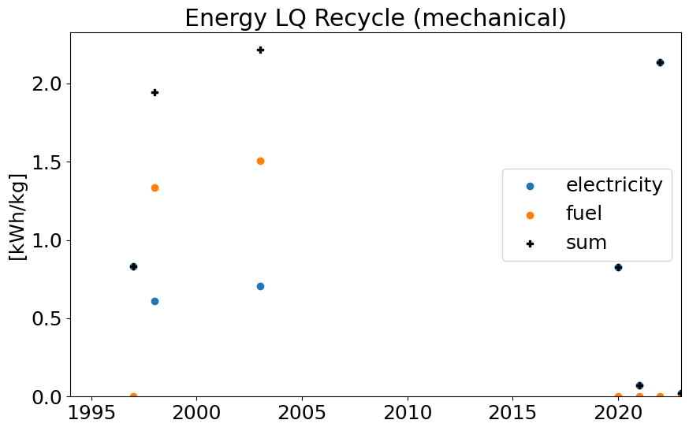

```python
plt.scatter(e_plastic_LQrecycle_raw.index, e_plastic_LQrecycle_raw.iloc[:,0], label='electricity', )
plt.scatter(e_plastic_LQrecycle_raw.index, e_plastic_LQrecycle_raw.iloc[:,3], label='fuel')
plt.scatter(e_plastic_LQrecycle_raw.index, e_plastic_LQrecycle_raw.iloc[:,6], label='sum', marker='P', color='black')

plt.title('Energy LQ Recycle (mechanical)')
plt.ylabel('[kWh/kg]')
plt.xlim(1994,2023)
plt.ylim(0,)
plt.legend()
```

Three of the data sources are in close agreement on the energy requirements. There is also useful data for decreasing fuel fraction from Uekert et al. Therefore, we will interpolate from Joosten, Arena, and Uekert.

```python
e_plastic_LQrecycle_maths = e_plastic_LQrecycle_raw.loc[[1998,2003,2022],['E_LQrecycle_kWhpkg','E_LQrecycle_fuel_kWhpkg']]
e_plastic_LQrecycle_maths.loc[2022,'E_LQrecycle_fuel_kWhpkg'] = 0.03*8.58*0.277777 #from Uekert supplemental
e_plastic_LQrecycle_maths['E_LQrecycle_sum_kWhpkg'] = e_plastic_LQrecycle_maths.sum(axis=1)
e_plastic_LQrecycle_maths['E_LQrecycle_fuelfraction'] = e_plastic_LQrecycle_maths['E_LQrecycle_fuel_kWhpkg']/e_plastic_LQrecycle_maths['E_LQrecycle_sum_kWhpkg']
e_plastic_LQrecycle_maths
```

| year | E_LQrecycle_kWhpkg | E_LQrecycle_fuel_kWhpkg | E_LQrecycle_sum_kWhpkg | E_LQrecycle_fuelfraction |
| --- | --- | --- | --- | --- |
| 1998 | 0.611100 | 1.333000 | 1.944100 | 0.685664 |
| 2003 | 0.705554 | 1.508329 | 2.213883 | 0.681305 |
| 2022 | 2.135000 | 0.071500 | 2.206500 | 0.032404 |

```python
idx_temp = pd.Series(range(1995,2051,1))
E_plastic_LQrecycle_temp = e_plastic_LQrecycle_maths.iloc[:,[2,3]]
E_plastic_LQrecycle_gappy = E_plastic_LQrecycle_temp.reindex(index=idx_temp)
E_plastic_LQrecycle = E_plastic_LQrecycle_gappy.interpolate(limit_direction='both')
```

```python
E_plastic_LQrecycle.to_csv(cwd+"/../../../PV_ICE/baselines/SupportingMaterial/output_energy_plastics_LQrecycle.csv")
```

### HQ recycling

These numbers will be added to the LQ recycling numbers

```python
cwd = os.getcwd() #grabs current working directory
#skipcols = ['Source', 'Notes','Country']
e_plastic_HQrecycle_raw = pd.read_csv(cwd+"/../../../PV_ICE/baselines/SupportingMaterial/energy-input-plastic-HQrecycling.csv",
                                     index_col='year')#, usecols=lambda x: x not in skipcols)
```

```python
e_plastic_HQrecycle_raw['E_sum_kWhpkg'] = e_plastic_HQrecycle_raw['E_HQrecycle_kWhpkg']+e_plastic_HQrecycle_raw['E_HQrecycle_fuel_kWhpkg']
```

```python
e_plastic_HQrecycle_raw.dropna(how='all')
```

| year | E_HQrecycle_kWhpkg | Source | Notes | E_HQrecycle_fuel_kWhpkg | Source.1 | Notes.1 | E_sum_kWhpkg |
| --- | --- | --- | --- | --- | --- | --- | --- |
| 2006 | 0.200000 | Neelis, M. et al. (2007) ‘Approximation of the... | A1, vinyl chloride from ethylene | 1.000000 | Neelis, M. et al. (2007) ‘Approximation of the... | A1, vinyl chloride from ethylene, plus some steam | 1.200000 |
| 2007 | 0.566700 | Neelis, M. et al. (2007) ‘Approximation of the... | A1, polyethylene (add to ethylene) | 8.931000 | Neelis, M. et al. (2007) ‘Approximation of the... | A1, Ethylene | 9.497700 |
| 2015 | 0.400000 | Golkaram, M., and L.P. Heemskerk. 2022. “Compa... | Table 10, PET pyrolysis | 0.049231 | Golkaram, M., and L.P. Heemskerk. 2022. “Compa... | Table 10, PET pyrollysis "heat" | 0.449231 |
| 2019 | 16.212509 | Uekert, T. et al. (2023) ‘Technical, Economic,... | Table S27, CED, Dissolution, enzymatic, glycol... | 6.347197 | Uekert, T. et al. (2023) ‘Technical, Economic,... | Table S27, CED, Dissolution, enzymatic, glycol... | 22.559706 |
| 2020 | 2.506710 | Uekert, T. et al. (2023) ‘Technical, Economic,... | Table S27, CED*.1243 from electricity table S3... | 12.160466 | Uekert, T. et al. (2023) ‘Technical, Economic,... | Table S27, CED*.603 from steam table S34, Meth... | 14.667176 |
| 2021 | 0.380430 | Xayachak, T. et al. (2023) ‘Assessing the envi... | Table S6, (HQCL) monomer recovery through pyro... | 0.249470 | Xayachak, T. et al. (2023) ‘Assessing the envi... | Table S6, (HQCL) monomer recovery through pyro... | 0.629900 |
| 2022 | 0.679550 | Xayachak, T. et al. (2023) ‘Assessing the envi... | Table S7 (HQOL) high value chemical (usual fue... | 0.702508 | Xayachak, T. et al. (2023) ‘Assessing the envi... | Table S7 (HQOL) high value chemical (usual fue... | 1.382058 |

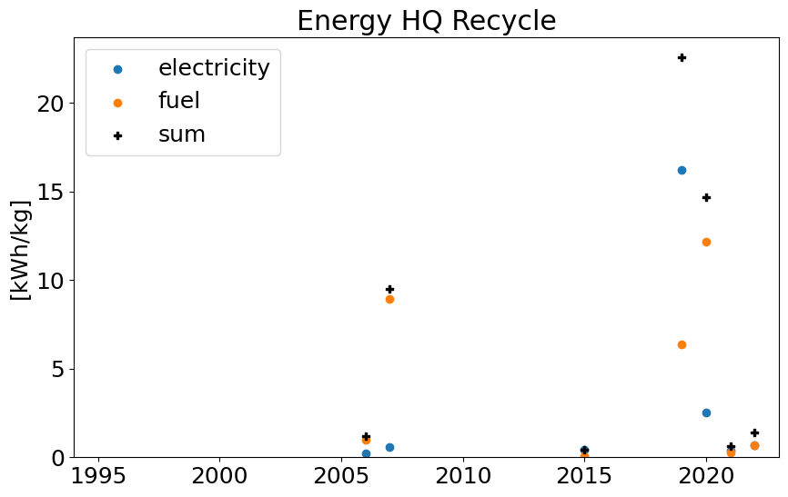

```python
plt.scatter(e_plastic_HQrecycle_raw.index, e_plastic_HQrecycle_raw.iloc[:,0], label='electricity', )
plt.scatter(e_plastic_HQrecycle_raw.index, e_plastic_HQrecycle_raw.iloc[:,3], label='fuel')
plt.scatter(e_plastic_HQrecycle_raw.index, e_plastic_HQrecycle_raw.iloc[:,6], label='sum', marker='P', color='black')

plt.title('Energy HQ Recycle')
plt.ylabel('[kWh/kg]')
plt.xlim(1994,2023)
plt.ylim(0,)
plt.legend()
```

We will select the Uekert methanolysis (of PET) values for HQ closed loop recycling, as it is indicated that this process produces a high material quality with no discoloration.

```python
e_plasticHQrecyle_fuelfraction = e_plastic_HQrecycle_raw.loc[2020,'E_HQrecycle_fuel_kWhpkg']/e_plastic_HQrecycle_raw.loc[2020,'E_sum_kWhpkg']
```

```python
idx_temp = pd.Series(range(1995,2051,1))
E_plastic_HQrecycle = pd.DataFrame(index=idx_temp)
E_plastic_HQrecycle['E_HQrecycle_kWhpkg'] = e_plastic_HQrecycle_raw.loc[2020,'E_sum_kWhpkg']
E_plastic_HQrecycle['E_HQrecycle_fuelfraction'] = e_plasticHQrecyle_fuelfraction
```

```python
E_plastic_HQrecycle.head()
```

|  | E_HQrecycle_kWhpkg | E_HQrecycle_fuelfraction |
| --- | --- | --- |
| 1995 | 14.667176 | 0.829094 |
| 1996 | 14.667176 | 0.829094 |
| 1997 | 14.667176 | 0.829094 |
| 1998 | 14.667176 | 0.829094 |
| 1999 | 14.667176 | 0.829094 |